# Google_playstore_app data.

# Domain: Social media

# 1. Import required libraries and read the dataset.

```python
#required libraries which I used for EDA:
import pandas as pd
import numpy as np
import matplotlib.pyplot as plt
import seaborn as sns
import warnings

# Suppress warnings for cleaner output
warnings.filterwarnings("ignore")
```

```python
# Read the dataset
gpa = pd.read_csv('Apps_data+(1).csv')
```

```python
# Display the first few rows of the dataset
gpa
```

|  | App | Category | Rating | Reviews | Size | Installs | Type | Price | Content Rating | Genres | Last Updated | Current Ver | Android Ver |
| --- | --- | --- | --- | --- | --- | --- | --- | --- | --- | --- | --- | --- | --- |
| 0 | Photo Editor & Candy Camera & Grid & ScrapBook | ART_AND_DESIGN | 4.1 | 159 | 19M | 10,000+ | Free | 0 | Everyone | Art & Design | January 7, 2018 | 1.0.0 | 4.0.3 and up |
| 1 | Coloring book moana | ART_AND_DESIGN | 3.9 | 967 | 14M | 500,000+ | Free | 0 | Everyone | Art & Design;Pretend Play | January 15, 2018 | 2.0.0 | 4.0.3 and up |
| 2 | U Launcher Lite – FREE Live Cool Themes, Hide ... | ART_AND_DESIGN | 4.7 | 87510 | 8.7M | 5,000,000+ | Free | 0 | Everyone | Art & Design | August 1, 2018 | 1.2.4 | 4.0.3 and up |
| 3 | Sketch - Draw & Paint | ART_AND_DESIGN | 4.5 | 215644 | 25M | 50,000,000+ | Free | 0 | Teen | Art & Design | June 8, 2018 | Varies with device | 4.2 and up |
| 4 | Pixel Draw - Number Art Coloring Book | ART_AND_DESIGN | 4.3 | 967 | 2.8M | 100,000+ | Free | 0 | Everyone | Art & Design;Creativity | June 20, 2018 | 1.1 | 4.4 and up |
| ... | ... | ... | ... | ... | ... | ... | ... | ... | ... | ... | ... | ... | ... |
| 10836 | Sya9a Maroc - FR | FAMILY | 4.5 | 38 | 53M | 5,000+ | Free | 0 | Everyone | Education | July 25, 2017 | 1.48 | 4.1 and up |
| 10837 | Fr. Mike Schmitz Audio Teachings | FAMILY | 5.0 | 4 | 3.6M | 100+ | Free | 0 | Everyone | Education | July 6, 2018 | 1.0 | 4.1 and up |
| 10838 | Parkinson Exercices FR | MEDICAL | NaN | 3 | 9.5M | 1,000+ | Free | 0 | Everyone | Medical | January 20, 2017 | 1.0 | 2.2 and up |
| 10839 | The SCP Foundation DB fr nn5n | BOOKS_AND_REFERENCE | 4.5 | 114 | Varies with device | 1,000+ | Free | 0 | Mature 17+ | Books & Reference | January 19, 2015 | Varies with device | Varies with device |
| 10840 | iHoroscope - 2018 Daily Horoscope & Astrology | LIFESTYLE | 4.5 | 398307 | 19M | 10,000,000+ | Free | 0 | Everyone | Lifestyle | July 25, 2018 | Varies with device | Varies with device |

10841 rows × 13 columns

```python
print(gpa)
```

```
                                                     App             Category  \
0         Photo Editor & Candy Camera & Grid & ScrapBook       ART_AND_DESIGN
1                                    Coloring book moana       ART_AND_DESIGN
2      U Launcher Lite – FREE Live Cool Themes, Hide ...       ART_AND_DESIGN
3                                  Sketch - Draw & Paint       ART_AND_DESIGN
4                  Pixel Draw - Number Art Coloring Book       ART_AND_DESIGN
...                                                  ...                  ...
10836                                   Sya9a Maroc - FR               FAMILY
10837                   Fr. Mike Schmitz Audio Teachings               FAMILY
10838                             Parkinson Exercices FR              MEDICAL
10839                      The SCP Foundation DB fr nn5n  BOOKS_AND_REFERENCE
10840      iHoroscope - 2018 Daily Horoscope & Astrology            LIFESTYLE

       Rating Reviews                Size     Installs  Type Price  \
0         4.1     159                 19M      10,000+  Free     0
```

[output cut: 38 more lines]

This script imports the "pandas","Numpy","matplotlib.pyplot","seaborn","warnings"- library, reads the dataset from the CSV file, and displays the dataset.

# 2. Check the first few samples, shape, info of the data and try to familiarize yourself with different features.

```python
# Display the first few samples
print("First few samples:")
print(gpa.head())
```

```
First few samples:
                                                 App        Category  Rating  \
0     Photo Editor & Candy Camera & Grid & ScrapBook  ART_AND_DESIGN     4.1
1                                Coloring book moana  ART_AND_DESIGN     3.9
2  U Launcher Lite – FREE Live Cool Themes, Hide ...  ART_AND_DESIGN     4.7
3                              Sketch - Draw & Paint  ART_AND_DESIGN     4.5
4              Pixel Draw - Number Art Coloring Book  ART_AND_DESIGN     4.3

  Reviews  Size     Installs  Type Price Content Rating  \
0     159   19M      10,000+  Free     0       Everyone
1     967   14M     500,000+  Free     0       Everyone
2   87510  8.7M   5,000,000+  Free     0       Everyone
3  215644   25M  50,000,000+  Free     0           Teen
4     967  2.8M     100,000+  Free     0       Everyone

                      Genres      Last Updated         Current Ver  \
0               Art & Design   January 7, 2018               1.0.0
1  Art & Design;Pretend Play  January 15, 2018               2.0.0
2               Art & Design    August 1, 2018               1.2.4
3               Art & Design      June 8, 2018  Varies with device
4    Art & Design;Creativity     June 20, 2018                 1.1

    Android Ver
0  4.0.3 and up
1  4.0.3 and up
2  4.0.3 and up
3    4.2 and up
4    4.4 and up
```

```python
# Display the shape of the dataset (number of rows and columns)
print("\nShape of the dataset:")
print(gpa.shape)
```

```
Shape of the dataset:
(10841, 13)
```

```python
# Display information about the dataset
print("\nInfo of the dataset:")
print(gpa.info())
```

```
Info of the dataset:
<class 'pandas.core.frame.DataFrame'>
RangeIndex: 10841 entries, 0 to 10840
Data columns (total 13 columns):
 #   Column          Non-Null Count  Dtype
---  ------          --------------  -----
 0   App             10841 non-null  object
 1   Category        10841 non-null  object
 2   Rating          9367 non-null   float64
 3   Reviews         10841 non-null  object
 4   Size            10841 non-null  object
 5   Installs        10841 non-null  object
 6   Type            10840 non-null  object
 7   Price           10841 non-null  object
 8   Content Rating  10840 non-null  object
 9   Genres          10841 non-null  object
 10  Last Updated    10841 non-null  object
 11  Current Ver     10833 non-null  object
 12  Android Ver     10838 non-null  object
dtypes: float64(1), object(12)
memory usage: 1.1+ MB
None
```

It provided shows the first few samples of the dataset, its shape, and its information. Here's a summary of what you've displayed:

1. The dataset has 10,841 rows and 13 columns.
2. The dataset contains information about mobile apps, including their names, categories, ratings, reviews, sizes, installation numbers, types (Free or Paid), prices, content ratings, genres, last update dates, current versions, and required Android versions.
3. There are some missing values in columns such as "Rating," "Type," "Content Rating," "Current Ver," and "Android Ver."
4. The data types of the columns vary, with most being of type "object" (usually representing strings), and one column ("Rating") being of type "float64."

# 3. Check summary statistics of the dataset. List out the columns that need to be worked upon for model building.

```python
# Display summary statistics of numeric columns
print(gpa.describe())
```

```
            Rating
count  9367.000000
mean      4.193338
std       0.537431
min       1.000000
25%       4.000000
50%       4.300000
75%       4.500000
max      19.000000
```

The summary statistics you've provided are for the "Rating" column:

- Count: 9367
- Mean: 4.193338
- Standard Deviation (Std): 0.537431
- Minimum (Min): 1.000000
- 25th Percentile (25%): 4.000000
- Median (50% or Q2): 4.300000
- 75th Percentile (75%): 4.500000
- Maximum (Max): 19.000000

From these statistics, you can observe a few things about the "Rating" column:

- The mean rating is around 4.19, indicating that apps generally have good ratings.
- The standard deviation is relatively low, suggesting that the ratings are not very spread out.
- The minimum rating is 1, and the maximum rating is 19, which is likely an outlier. Ratings are typically between 1 and 5.
- The median rating (4.3) is close to the 75th percentile (4.5), indicating that the distribution might be slightly skewed towards higher ratings.

# 4. Check if there are any duplicate records in the dataset? if any drop them.

```python
# Check for duplicate records
duplicate_rows = gpa[gpa.duplicated()]

# Display the number of duplicate records
print("Number of duplicate records:", duplicate_rows.shape[0])
```

```
Number of duplicate records: 483
```

```python
# Drop duplicate records
gpa_cleaned = gpa.drop_duplicates()

# Display the shape of the cleaned dataset
print("Shape of the cleaned dataset:", gpa_cleaned.shape)
```

```
Shape of the cleaned dataset: (10358, 13)
```

It appears that there were 483 duplicate records in the original dataset. After removing these duplicates, the cleaned dataset now has a shape of (10358, 13), which means you have 10,358 unique records remaining. Removing duplicate records is an important step to ensure the quality and accuracy of your analysis or model building process.

# 5. Check the unique categories of the column 'Category', Is there any invalid category? If yes, drop them.

```python
# Count occurrences of each unique category
category_counts = gpa_cleaned['Category'].value_counts()

# Print the category counts
print("unique categories of the column",category_counts)
```

```
unique categories of the column Category
FAMILY                 1943
GAME                   1121
TOOLS                   843
BUSINESS                427
MEDICAL                 408
PRODUCTIVITY            407
PERSONALIZATION         388
LIFESTYLE               373
COMMUNICATION           366
FINANCE                 360
SPORTS                  351
PHOTOGRAPHY             322
HEALTH_AND_FITNESS      306
SOCIAL                  280
NEWS_AND_MAGAZINES      264
TRAVEL_AND_LOCAL        237
BOOKS_AND_REFERENCE     230
SHOPPING                224
DATING                  196
VIDEO_PLAYERS           175
MAPS_AND_NAVIGATION     137
EDUCATION               130
FOOD_AND_DRINK          124
ENTERTAINMENT           111
AUTO_AND_VEHICLES        85
LIBRARIES_AND_DEMO       85
WEATHER                  82
HOUSE_AND_HOME           80
ART_AND_DESIGN           65
EVENTS                   64
PARENTING                60
COMICS                   60
BEAUTY                   53
1.9                       1
Name: count, dtype: int64
```

The output you provided shows the counts of each category in the 'Category' column of the cleaned dataset. It appears that there might be an invalid category with the label "1.9" since it has only one occurrence. This could be a data entry error or anomaly.

If you're certain that "1.9" is not a valid category and is likely an error, you should remove this row from the dataset. Here's how you can do it:

```python
# Remove rows with invalid category "1.9"
gpa_cleaned = gpa_cleaned[gpa_cleaned['Category'] != '1.9']

# Print the shape of the cleaned dataset after removing the invalid category
print("Shape of the cleaned dataset:", gpa_cleaned.shape)
```

```
Shape of the cleaned dataset: (10357, 13)
```

This code removes the rows with the invalid category "1.9" from the cleaned dataset. After running this code, you'll have a dataset without the invalid category. The shape of the cleaned dataset is now (10357, 13), indicating that you have 10,357 rows and 13 columns remaining after dropping the invalid category.

# 6. Check if there are missing values present in the column Rating, If any? drop them and and create a new column as 'Rating_category' by converting ratings to high and low categories(>3.5 is high rest low)

```python
# Check for missing values in the 'Rating' column
missing_rating = gpa_cleaned['Rating'].isnull()

# Count the number of missing values
num_missing = missing_rating.sum()

# Print the number of missing values
print("Number of missing values in 'Rating' column:", num_missing)
```

```
Number of missing values in 'Rating' column: 1465
```

```python
# Drop rows with missing values in the 'Rating' column
gpa_no_missing_rating = gpa_cleaned.dropna(subset=['Rating'])

# Create a new column 'Rating_category'
gpa_no_missing_rating['Rating_category'] = gpa_no_missing_rating['Rating'].apply(lambda x: 'high' if x > 3.5 else 'low')

# Print the shape of the dataset after removing missing values
print("Shape of the dataset without missing values:", gpa_no_missing_rating.shape)
```

```
Shape of the dataset without missing values: (8892, 14)
```

It successfully removed the rows with missing values in the 'Rating' column and created a new 'Rating_category' column based on the rating values. The dataset now has a shape of (8892, 14), indicating that you have 8892 rows and 14 columns after these operations.

# 7. Check the distribution of the newly created column 'Rating_category' and comment on the distribution.

```python
# Check the distribution of the 'Rating_category' column
rating_category_distribution = gpa_no_missing_rating['Rating_category'].value_counts()

# Print the distribution
print(rating_category_distribution)
```

```
Rating_category
high    8012
low      880
Name: count, dtype: int64
```

The distribution of the newly created 'Rating_category' column is as follows:

"High" Ratings: 8012 instances, "Low" Ratings: 880 instances

This distribution suggests that a majority of the apps in the dataset are categorized as having "High" ratings, while a smaller proportion of apps are categorized as having "Low" ratings. This information can be useful for understanding the overall quality perception of the apps based on their ratings.

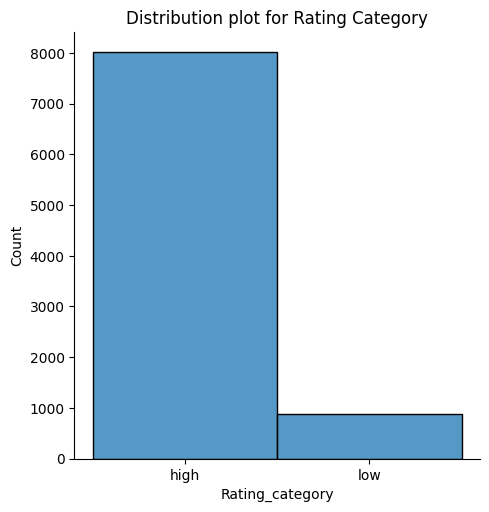

```python
# Plot the distribution
# Create a distribution plot for Rating Category
sns.displot(gpa_no_missing_rating['Rating_category'])
plt.title('Distribution plot for Rating Category');
```

The provided code snippet leverages Seaborn, a popular data visualization library, to craft a distribution plot that vividly illustrates the distribution of the 'Rating_category' column. This column encapsulates the categorical classification of app ratings into two distinct categories: "High" and "Low". This visualization empowers us to discern the distribution of these categorical classifications with a quick glance.

# 8. Convert the column "Reviews'' to numeric data type and check the presence of outliers in the column and handle the outliers using a transformation approach.(Hint: Use log transformation)

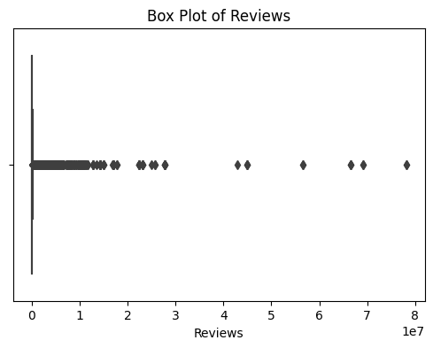

```python
# Convert 'Reviews' column to numeric
gpa_cleaned['Reviews'] = pd.to_numeric(gpa_cleaned['Reviews'], errors='coerce')

# Check for outliers using box plot
plt.figure(figsize=(6,4))
sns.boxplot(x=gpa_cleaned['Reviews'])
plt.title('Box Plot of Reviews')
plt.xlabel('Reviews');
```

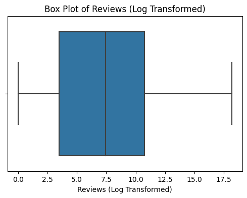

```python
# Apply log transformation to handle outliers
gpa_cleaned['Reviews_log'] = np.log1p(gpa_cleaned['Reviews'])

# Check for outliers in the transformed column
plt.figure(figsize=(6,4))
sns.boxplot(x=gpa_cleaned['Reviews_log'])
plt.title('Box Plot of Reviews (Log Transformed)')
plt.xlabel('Reviews (Log Transformed)');
```

# 9. The column 'Size' contains alphanumeric values, treat the non numeric data and convert the column into suitable data type. (hint: Replace M with 1 million and K with 1 thousand, and drop the entries where size='Varies with device')

```python
# Replace 'M' with 1 million and 'K' with 1 thousand, and convert to numeric
gpa_no_missing_rating['Size'] = gpa_no_missing_rating['Size'].replace(['M', 'K'], ['', ''], regex=True)
gpa_no_missing_rating['Size'] = pd.to_numeric(gpa_no_missing_rating['Size'], errors='coerce')

# Drop entries where size is 'Varies with device'
gpa_cleaned_size = gpa_no_missing_rating[gpa_no_missing_rating['Size'] != 'Varies with device']

# Print the shape of the dataset after size treatment
print("Shape of the dataset after size treatment:", gpa_cleaned_size.shape)
```

```
Shape of the dataset after size treatment: (8892, 14)
```

```python
gpa_cleaned_size
```

|  | App | Category | Rating | Reviews | Size | Installs | Type | Price | Content Rating | Genres | Last Updated | Current Ver | Android Ver | Rating_category |
| --- | --- | --- | --- | --- | --- | --- | --- | --- | --- | --- | --- | --- | --- | --- |
| 0 | Photo Editor & Candy Camera & Grid & ScrapBook | ART_AND_DESIGN | 4.1 | 159 | 19.0 | 10,000+ | Free | 0 | Everyone | Art & Design | January 7, 2018 | 1.0.0 | 4.0.3 and up | high |
| 1 | Coloring book moana | ART_AND_DESIGN | 3.9 | 967 | 14.0 | 500,000+ | Free | 0 | Everyone | Art & Design;Pretend Play | January 15, 2018 | 2.0.0 | 4.0.3 and up | high |
| 2 | U Launcher Lite – FREE Live Cool Themes, Hide ... | ART_AND_DESIGN | 4.7 | 87510 | 8.7 | 5,000,000+ | Free | 0 | Everyone | Art & Design | August 1, 2018 | 1.2.4 | 4.0.3 and up | high |
| 3 | Sketch - Draw & Paint | ART_AND_DESIGN | 4.5 | 215644 | 25.0 | 50,000,000+ | Free | 0 | Teen | Art & Design | June 8, 2018 | Varies with device | 4.2 and up | high |
| 4 | Pixel Draw - Number Art Coloring Book | ART_AND_DESIGN | 4.3 | 967 | 2.8 | 100,000+ | Free | 0 | Everyone | Art & Design;Creativity | June 20, 2018 | 1.1 | 4.4 and up | high |
| ... | ... | ... | ... | ... | ... | ... | ... | ... | ... | ... | ... | ... | ... | ... |
| 10834 | FR Calculator | FAMILY | 4.0 | 7 | 2.6 | 500+ | Free | 0 | Everyone | Education | June 18, 2017 | 1.0.0 | 4.1 and up | high |
| 10836 | Sya9a Maroc - FR | FAMILY | 4.5 | 38 | 53.0 | 5,000+ | Free | 0 | Everyone | Education | July 25, 2017 | 1.48 | 4.1 and up | high |
| 10837 | Fr. Mike Schmitz Audio Teachings | FAMILY | 5.0 | 4 | 3.6 | 100+ | Free | 0 | Everyone | Education | July 6, 2018 | 1.0 | 4.1 and up | high |
| 10839 | The SCP Foundation DB fr nn5n | BOOKS_AND_REFERENCE | 4.5 | 114 | NaN | 1,000+ | Free | 0 | Mature 17+ | Books & Reference | January 19, 2015 | Varies with device | Varies with device | high |
| 10840 | iHoroscope - 2018 Daily Horoscope & Astrology | LIFESTYLE | 4.5 | 398307 | 19.0 | 10,000,000+ | Free | 0 | Everyone | Lifestyle | July 25, 2018 | Varies with device | Varies with device | high |

8892 rows × 14 columns

# 10. Check the column 'Installs', treat the unwanted characters and convert the column into a suitable data type.

```python
# Remove unwanted characters from 'Installs' column
gpa_cleaned['Installs'] = gpa_cleaned['Installs'].str.replace(',', '').str.replace('+', '')

# Convert 'Installs' column to numeric
gpa_cleaned['Installs'] = pd.to_numeric(gpa_cleaned['Installs'], errors='coerce')

# Display the first few rows of the updated dataset
print(gpa_cleaned.head())
```

```
                                                 App        Category  Rating  \
0     Photo Editor & Candy Camera & Grid & ScrapBook  ART_AND_DESIGN     4.1
1                                Coloring book moana  ART_AND_DESIGN     3.9
2  U Launcher Lite – FREE Live Cool Themes, Hide ...  ART_AND_DESIGN     4.7
3                              Sketch - Draw & Paint  ART_AND_DESIGN     4.5
4              Pixel Draw - Number Art Coloring Book  ART_AND_DESIGN     4.3

   Reviews  Size  Installs  Type Price Content Rating  \
0      159   19M     10000  Free     0       Everyone
1      967   14M    500000  Free     0       Everyone
2    87510  8.7M   5000000  Free     0       Everyone
3   215644   25M  50000000  Free     0           Teen
4      967  2.8M    100000  Free     0       Everyone

                      Genres      Last Updated         Current Ver  \
0               Art & Design   January 7, 2018               1.0.0
1  Art & Design;Pretend Play  January 15, 2018               2.0.0
2               Art & Design    August 1, 2018               1.2.4
3               Art & Design      June 8, 2018  Varies with device
4    Art & Design;Creativity     June 20, 2018                 1.1

    Android Ver  Reviews_log
0  4.0.3 and up     5.075174
1  4.0.3 and up     6.875232
2  4.0.3 and up    11.379520
3    4.2 and up    12.281389
4    4.4 and up     6.875232
```

```python
gpa_cleaned
```

|  | App | Category | Rating | Reviews | Size | Installs | Type | Price | Content Rating | Genres | Last Updated | Current Ver | Android Ver | Reviews_log |
| --- | --- | --- | --- | --- | --- | --- | --- | --- | --- | --- | --- | --- | --- | --- |
| 0 | Photo Editor & Candy Camera & Grid & ScrapBook | ART_AND_DESIGN | 4.1 | 159 | 19M | 10000 | Free | 0 | Everyone | Art & Design | January 7, 2018 | 1.0.0 | 4.0.3 and up | 5.075174 |
| 1 | Coloring book moana | ART_AND_DESIGN | 3.9 | 967 | 14M | 500000 | Free | 0 | Everyone | Art & Design;Pretend Play | January 15, 2018 | 2.0.0 | 4.0.3 and up | 6.875232 |
| 2 | U Launcher Lite – FREE Live Cool Themes, Hide ... | ART_AND_DESIGN | 4.7 | 87510 | 8.7M | 5000000 | Free | 0 | Everyone | Art & Design | August 1, 2018 | 1.2.4 | 4.0.3 and up | 11.379520 |
| 3 | Sketch - Draw & Paint | ART_AND_DESIGN | 4.5 | 215644 | 25M | 50000000 | Free | 0 | Teen | Art & Design | June 8, 2018 | Varies with device | 4.2 and up | 12.281389 |
| 4 | Pixel Draw - Number Art Coloring Book | ART_AND_DESIGN | 4.3 | 967 | 2.8M | 100000 | Free | 0 | Everyone | Art & Design;Creativity | June 20, 2018 | 1.1 | 4.4 and up | 6.875232 |
| ... | ... | ... | ... | ... | ... | ... | ... | ... | ... | ... | ... | ... | ... | ... |
| 10836 | Sya9a Maroc - FR | FAMILY | 4.5 | 38 | 53M | 5000 | Free | 0 | Everyone | Education | July 25, 2017 | 1.48 | 4.1 and up | 3.663562 |
| 10837 | Fr. Mike Schmitz Audio Teachings | FAMILY | 5.0 | 4 | 3.6M | 100 | Free | 0 | Everyone | Education | July 6, 2018 | 1.0 | 4.1 and up | 1.609438 |
| 10838 | Parkinson Exercices FR | MEDICAL | NaN | 3 | 9.5M | 1000 | Free | 0 | Everyone | Medical | January 20, 2017 | 1.0 | 2.2 and up | 1.386294 |
| 10839 | The SCP Foundation DB fr nn5n | BOOKS_AND_REFERENCE | 4.5 | 114 | Varies with device | 1000 | Free | 0 | Mature 17+ | Books & Reference | January 19, 2015 | Varies with device | Varies with device | 4.744932 |
| 10840 | iHoroscope - 2018 Daily Horoscope & Astrology | LIFESTYLE | 4.5 | 398307 | 19M | 10000000 | Free | 0 | Everyone | Lifestyle | July 25, 2018 | Varies with device | Varies with device | 12.894981 |

10357 rows × 14 columns

# 11. Check the column 'Price' , remove the unwanted characters and convert the column into a suitable data type.

```python
gpa['Price']
```

```
0        0
1        0
2        0
3        0
4        0
        ..
10836    0
10837    0
10838    0
10839    0
10840    0
Name: Price, Length: 10841, dtype: object
```

```python
# Clean the 'Price' column by removing unwanted characters and convert to numeric
gpa_cleaned_size['Price'] = gpa_cleaned_size['Price'].str.replace('[\$,]', '', regex=True)
gpa_cleaned_size['Price'] = pd.to_numeric(gpa_cleaned_size['Price'], errors='coerce')

# Print the data type of the 'Price' column after treatment
print("Data type of 'Price' column after treatment:", gpa_cleaned_size['Price'].dtype)
```

```
Data type of 'Price' column after treatment: float64
```

```python
# Convert the 'Price' column to integer
gpa_cleaned_size['Price'] = gpa_cleaned_size['Price'].astype(int)

# Print the data type of the 'Price' column after converting to integer
print("Data type of 'Price' column after converting to integer:", gpa_cleaned_size['Price'].dtype)
```

```
Data type of 'Price' column after converting to integer: int32
```

```python
gpa_cleaned_size
```

|  | App | Category | Rating | Reviews | Size | Installs | Type | Price | Content Rating | Genres | Last Updated | Current Ver | Android Ver | Rating_category |
| --- | --- | --- | --- | --- | --- | --- | --- | --- | --- | --- | --- | --- | --- | --- |
| 0 | Photo Editor & Candy Camera & Grid & ScrapBook | ART_AND_DESIGN | 4.1 | 159 | 19.0 | 10,000+ | Free | 0 | Everyone | Art & Design | January 7, 2018 | 1.0.0 | 4.0.3 and up | high |
| 1 | Coloring book moana | ART_AND_DESIGN | 3.9 | 967 | 14.0 | 500,000+ | Free | 0 | Everyone | Art & Design;Pretend Play | January 15, 2018 | 2.0.0 | 4.0.3 and up | high |
| 2 | U Launcher Lite – FREE Live Cool Themes, Hide ... | ART_AND_DESIGN | 4.7 | 87510 | 8.7 | 5,000,000+ | Free | 0 | Everyone | Art & Design | August 1, 2018 | 1.2.4 | 4.0.3 and up | high |
| 3 | Sketch - Draw & Paint | ART_AND_DESIGN | 4.5 | 215644 | 25.0 | 50,000,000+ | Free | 0 | Teen | Art & Design | June 8, 2018 | Varies with device | 4.2 and up | high |
| 4 | Pixel Draw - Number Art Coloring Book | ART_AND_DESIGN | 4.3 | 967 | 2.8 | 100,000+ | Free | 0 | Everyone | Art & Design;Creativity | June 20, 2018 | 1.1 | 4.4 and up | high |
| ... | ... | ... | ... | ... | ... | ... | ... | ... | ... | ... | ... | ... | ... | ... |
| 10834 | FR Calculator | FAMILY | 4.0 | 7 | 2.6 | 500+ | Free | 0 | Everyone | Education | June 18, 2017 | 1.0.0 | 4.1 and up | high |
| 10836 | Sya9a Maroc - FR | FAMILY | 4.5 | 38 | 53.0 | 5,000+ | Free | 0 | Everyone | Education | July 25, 2017 | 1.48 | 4.1 and up | high |
| 10837 | Fr. Mike Schmitz Audio Teachings | FAMILY | 5.0 | 4 | 3.6 | 100+ | Free | 0 | Everyone | Education | July 6, 2018 | 1.0 | 4.1 and up | high |
| 10839 | The SCP Foundation DB fr nn5n | BOOKS_AND_REFERENCE | 4.5 | 114 | NaN | 1,000+ | Free | 0 | Mature 17+ | Books & Reference | January 19, 2015 | Varies with device | Varies with device | high |
| 10840 | iHoroscope - 2018 Daily Horoscope & Astrology | LIFESTYLE | 4.5 | 398307 | 19.0 | 10,000,000+ | Free | 0 | Everyone | Lifestyle | July 25, 2018 | Varies with device | Varies with device | high |

8892 rows × 14 columns

```python
gpa_cleaned_size['Price'].info()
```

```
<class 'pandas.core.series.Series'>
Index: 8892 entries, 0 to 10840
Series name: Price
Non-Null Count  Dtype
--------------  -----
8892 non-null   int32
dtypes: int32(1)
memory usage: 104.2 KB
```

It successfully converted the 'Price' column to the 'int32' data type after treating it for unwanted characters. The printed information indicates that all data type of the 'Price' column has been changed to 'int32'.

# 12. Drop the columns which you think redundant for the analysis.(suggestion: drop column 'rating', since we created a new feature from it (i.e. rating_category) and the columns 'App', 'Rating' ,'Genres','Last Updated', 'Current Ver','Android Ver' columns since which are redundant for our analysis)

```python
# List of columns to drop
columns_to_drop = ['App', 'Rating', 'Genres', 'Last Updated', 'Current Ver', 'Android Ver']

# Drop the redundant columns
gpa_cleaned_size_dropped = gpa_cleaned_size.drop(columns=columns_to_drop, axis=1)

# Display the first few rows of the dataset after dropping columns
print(gpa_cleaned_size_dropped.head())
```

```
         Category Reviews  Size     Installs  Type  Price Content Rating  \
0  ART_AND_DESIGN     159  19.0      10,000+  Free      0       Everyone
1  ART_AND_DESIGN     967  14.0     500,000+  Free      0       Everyone
2  ART_AND_DESIGN   87510   8.7   5,000,000+  Free      0       Everyone
3  ART_AND_DESIGN  215644  25.0  50,000,000+  Free      0           Teen
4  ART_AND_DESIGN     967   2.8     100,000+  Free      0       Everyone

  Rating_category
0            high
1            high
2            high
3            high
4            high
```

```python
gpa_cleaned_size_dropped
```

|  | Category | Reviews | Size | Installs | Type | Price | Content Rating | Rating_category |
| --- | --- | --- | --- | --- | --- | --- | --- | --- |
| 0 | ART_AND_DESIGN | 159 | 19.0 | 10,000+ | Free | 0 | Everyone | high |
| 1 | ART_AND_DESIGN | 967 | 14.0 | 500,000+ | Free | 0 | Everyone | high |
| 2 | ART_AND_DESIGN | 87510 | 8.7 | 5,000,000+ | Free | 0 | Everyone | high |
| 3 | ART_AND_DESIGN | 215644 | 25.0 | 50,000,000+ | Free | 0 | Teen | high |
| 4 | ART_AND_DESIGN | 967 | 2.8 | 100,000+ | Free | 0 | Everyone | high |
| ... | ... | ... | ... | ... | ... | ... | ... | ... |
| 10834 | FAMILY | 7 | 2.6 | 500+ | Free | 0 | Everyone | high |
| 10836 | FAMILY | 38 | 53.0 | 5,000+ | Free | 0 | Everyone | high |
| 10837 | FAMILY | 4 | 3.6 | 100+ | Free | 0 | Everyone | high |
| 10839 | BOOKS_AND_REFERENCE | 114 | NaN | 1,000+ | Free | 0 | Mature 17+ | high |
| 10840 | LIFESTYLE | 398307 | 19.0 | 10,000,000+ | Free | 0 | Everyone | high |

8892 rows × 8 columns

# 13. Encode the categorical columns.

"One-Hot Encoding" : Convert categorical variables into binary vectors where each category becomes a separate binary feature (column).

```python
# Perform one-hot encoding
gpa_encoded = pd.get_dummies(gpa_cleaned_size_dropped, columns=['Rating_category'])
```

```python
# Display the first few rows of the dataset with 'Rating_category' converted to float
gpa_encoded
```

|  | Category | Reviews | Size | Installs | Type | Price | Content Rating | Rating_category_high | Rating_category_low |
| --- | --- | --- | --- | --- | --- | --- | --- | --- | --- |
| 0 | ART_AND_DESIGN | 159 | 19.0 | 10,000+ | Free | 0 | Everyone | True | False |
| 1 | ART_AND_DESIGN | 967 | 14.0 | 500,000+ | Free | 0 | Everyone | True | False |
| 2 | ART_AND_DESIGN | 87510 | 8.7 | 5,000,000+ | Free | 0 | Everyone | True | False |
| 3 | ART_AND_DESIGN | 215644 | 25.0 | 50,000,000+ | Free | 0 | Teen | True | False |
| 4 | ART_AND_DESIGN | 967 | 2.8 | 100,000+ | Free | 0 | Everyone | True | False |
| ... | ... | ... | ... | ... | ... | ... | ... | ... | ... |
| 10834 | FAMILY | 7 | 2.6 | 500+ | Free | 0 | Everyone | True | False |
| 10836 | FAMILY | 38 | 53.0 | 5,000+ | Free | 0 | Everyone | True | False |
| 10837 | FAMILY | 4 | 3.6 | 100+ | Free | 0 | Everyone | True | False |
| 10839 | BOOKS_AND_REFERENCE | 114 | NaN | 1,000+ | Free | 0 | Mature 17+ | True | False |
| 10840 | LIFESTYLE | 398307 | 19.0 | 10,000,000+ | Free | 0 | Everyone | True | False |

8892 rows × 9 columns

"Label Encoding ": Convert categorical variables into numerical labels.

```python
from sklearn.preprocessing import LabelEncoder

# Create a LabelEncoder instance
label_encoder = LabelEncoder()

# Apply label encoding to categorical columns
categorical_columns = ['Category', 'Type', 'Content Rating', 'Rating_category']
for col in categorical_columns:
    gpa_cleaned_size_dropped[col] = label_encoder.fit_transform(gpa_cleaned_size_dropped[col])
```

```python
categorical_columns
```

```
['Category', 'Type', 'Content Rating', 'Rating_category']
```

```python
gpa_encoded.columns
```

```
Index(['Category', 'Reviews', 'Size', 'Installs', 'Type', 'Price',
       'Content Rating', 'Rating_category_high', 'Rating_category_low'],
      dtype='object')
```

# 14. Segregate the target and independent features (Hint: Use Rating_category as the target)

```python
# Segregate the target and independent features
X = gpa_encoded.drop(columns=['Rating_category_high'])
y = gpa_encoded['Rating_category_high']

# Change the float values of the target column to integers
y = y.astype(int)

# Display the first few rows of the independent features (X) and target (y)
print("Independent features (X):")
print(X.head())
print("\nTarget (y):")
print(y.head())
```

```
Independent features (X):
         Category Reviews  Size     Installs  Type  Price Content Rating  \
0  ART_AND_DESIGN     159  19.0      10,000+  Free      0       Everyone
1  ART_AND_DESIGN     967  14.0     500,000+  Free      0       Everyone
2  ART_AND_DESIGN   87510   8.7   5,000,000+  Free      0       Everyone
3  ART_AND_DESIGN  215644  25.0  50,000,000+  Free      0           Teen
4  ART_AND_DESIGN     967   2.8     100,000+  Free      0       Everyone

   Rating_category_low
0                False
1                False
2                False
3                False
4                False

Target (y):
0    1
1    1
2    1
3    1
4    1
Name: Rating_category_high, dtype: int32
```

# 15. Split the dataset into train and test.

```python
from sklearn.model_selection import train_test_split
```

```python
train,test = train_test_split(gpa_encoded, test_size=0.25, random_state=555)
```

```python
train
```

|  | Category | Reviews | Size | Installs | Type | Price | Content Rating | Rating_category_high | Rating_category_low |
| --- | --- | --- | --- | --- | --- | --- | --- | --- | --- |
| 168 | BOOKS_AND_REFERENCE | 21336 | 23.0 | 1,000,000+ | Free | 0 | Everyone | True | False |
| 922 | ENTERTAINMENT | 14807 | 19.0 | 1,000,000+ | Free | 0 | Teen | True | False |
| 3059 | SPORTS | 101 | 3.9 | 10,000+ | Free | 0 | Everyone | True | False |
| 9746 | FAMILY | 3482 | 37.0 | 500,000+ | Free | 0 | Everyone | True | False |
| 2803 | PHOTOGRAPHY | 109500 | 37.0 | 1,000,000+ | Free | 0 | Everyone | True | False |
| ... | ... | ... | ... | ... | ... | ... | ... | ... | ... |
| 8638 | GAME | 154108 | 78.0 | 5,000,000+ | Free | 0 | Everyone | True | False |
| 247 | BUSINESS | 4159 | 48.0 | 500,000+ | Free | 0 | Everyone | True | False |
| 8026 | FAMILY | 6784 | 13.0 | 500,000+ | Free | 0 | Everyone | True | False |
| 9088 | GAME | 120852 | 21.0 | 10,000,000+ | Free | 0 | Teen | True | False |
| 5552 | FAMILY | 410 | 28.0 | 10,000+ | Free | 0 | Teen | True | False |

6669 rows × 9 columns

```python
test
```

|  | Category | Reviews | Size | Installs | Type | Price | Content Rating | Rating_category_high | Rating_category_low |
| --- | --- | --- | --- | --- | --- | --- | --- | --- | --- |
| 7011 | FAMILY | 34279 | 24.0 | 1,000,000+ | Free | 0 | Everyone | True | False |
| 5238 | PHOTOGRAPHY | 2 | 7.5 | 500+ | Free | 0 | Everyone | True | False |
| 7423 | COMMUNICATION | 5 | 15.0 | 100+ | Free | 0 | Everyone | True | False |
| 9575 | GAME | 93608 | NaN | 10,000,000+ | Free | 0 | Everyone | True | False |
| 5913 | BUSINESS | 87 | 26.0 | 5,000+ | Free | 0 | Everyone | False | True |
| ... | ... | ... | ... | ... | ... | ... | ... | ... | ... |
| 10362 | HEALTH_AND_FITNESS | 38487 | 60.0 | 1,000,000+ | Free | 0 | Teen | True | False |
| 6086 | FAMILY | 123309 | 25.0 | 10,000,000+ | Free | 0 | Everyone 10+ | True | False |
| 3647 | WEATHER | 135337 | NaN | 5,000,000+ | Free | 0 | Everyone | True | False |
| 4545 | FAMILY | 6 | 2.9 | 1,000+ | Free | 0 | Everyone | False | True |
| 3651 | WEATHER | 2143 | NaN | 100,000+ | Free | 0 | Everyone | True | False |

2223 rows × 9 columns

# 16. Standardize the data, so that the values are within a particular range.

```python
from sklearn.preprocessing import StandardScaler
```

```python
test.isnull().sum()
```

```
Category                  0
Reviews                   0
Size                    407
Installs                  0
Type                      0
Price                     0
Content Rating            0
Rating_category_high      0
Rating_category_low       0
dtype: int64
```

```python
# Replace null values with 0 in specific columns
columns_to_replace_null_with_zero = ['Size']
test[columns_to_replace_null_with_zero] = test[columns_to_replace_null_with_zero].fillna(0)

# Verify that null values have been replaced
print(test.isnull().sum())
```

```
Category                0
Reviews                 0
Size                    0
Installs                0
Type                    0
Price                   0
Content Rating          0
Rating_category_high    0
Rating_category_low     0
dtype: int64
```

```python
from sklearn.preprocessing import MinMaxScaler
scl = MinMaxScaler()
columns = ['Reviews', 'Size', 'Installs', 'Price', 'Category_AUTO_AND_VEHICLES',
       'Category_BEAUTY', 'Category_BOOKS_AND_REFERENCE', 'Category_BUSINESS',
       'Category_COMICS', 'Category_EDUCATION', 'Category_ENTERTAINMENT',
       'Category_EVENTS', 'Category_FAMILY', 'Category_GAME',
       'Category_HEALTH_AND_FITNESS', 'Category_HOUSE_AND_HOME',
       'Category_LIBRARIES_AND_DEMO', 'Category_LIFESTYLE',
       'Category_MAPS_AND_NAVIGATION', 'Category_MEDICAL',
       'Category_NEWS_AND_MAGAZINES', 'Category_PARENTING',
       'Category_PERSONALIZATION', 'Category_PHOTOGRAPHY',
       'Category_PRODUCTIVITY', 'Category_SHOPPING', 'Category_SOCIAL',
       'Category_SPORTS', 'Category_TOOLS', 'Category_TRAVEL_AND_LOCAL',
       'Category_VIDEO_PLAYERS', 'Category_WEATHER', 'Type_Paid',
       'Content Rating_Everyone', 'Content Rating_Everyone 10+',
       'Content Rating_Mature 17+', 'Content Rating_Teen',
       'Content Rating_Unrated', 'Rating_Category_Low']
sdz = scl.fit_transform(gpa)
sdz_df = pd.DataFrame(sdz,columns = columns)
sdz_df
```

[output not shown]